# 36-315 Lab 05

Eu Jing Chua

Due Friday, Sept 27 2019 (6:30pm)

## Lab 05: Density Estimates and Conditional Distributions for Continuous Data

Using the tidyverse style guide.

# Problem 1

(5 points each)

**1-D Kernel Density Estimation for Continuous Data**

1. The density function computes kernel density estimates. The x are the values of points where density is to be estimated, and y is the corresponding density value.
2. The adjust parameter makes it easy to set a multiple of the default value.
3. Possible kernels are “gaussian”, “rectangular”, “triangular”, “epanechnikov”, “biweight”, “cosine” or “optcosine”.

# Problem 2

(5 points each)

**Estimating Continuous Densities**

1. to f)

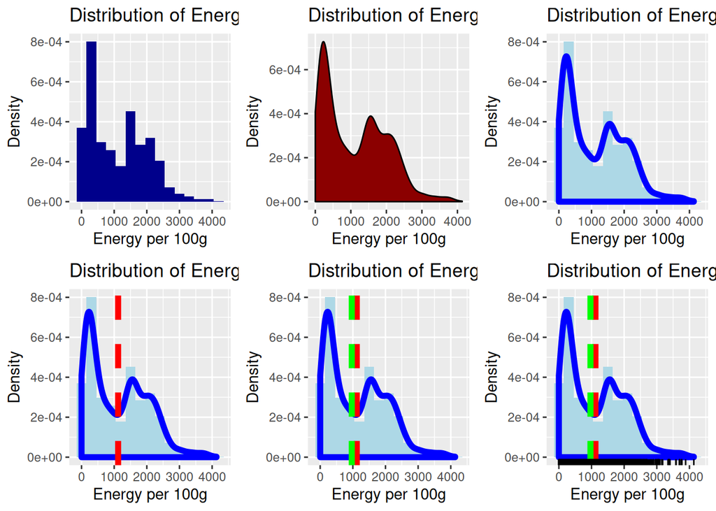

```r
library(tidyverse)
library(gridExtra)

food <- read_csv("https://raw.githubusercontent.com/mateyneykov/315_code_data/master/data/food-facts.csv")

glabs <- labs(x = "Energy per 100g", y = "Density",
              title = "Distribution of Energy per 100g")
g1 <- ggplot(food, aes(x = energy_100g)) +
    geom_histogram(aes(y = ..density..), fill = "darkblue", binwidth = 300) +
    glabs

g2 <- ggplot(food, aes(x = energy_100g)) +
    geom_density(fill = "darkred") +
    glabs

g3 <- ggplot(food, aes(x = energy_100g)) +
    geom_histogram(aes(y = ..density..), fill = "lightblue", binwidth = 300) +
    geom_density(color = "blue", size = 2) +
    glabs

g4 <- g3 + geom_vline(aes(xintercept = mean(energy_100g)),
                      color = "red",
                      linetype = "dashed",
                      size = 2)

g5 <- g4 + geom_vline(aes(xintercept = median(energy_100g)),
                      color = "green",
                      linetype = "dashed",
                      size = 2)

g6 <- g5 + geom_rug()

grid.arrange(g1, g2, g3, g4, g5, g6, nrow = 2, ncol = 3)
```

7. The graph from f) gives the most information, but e) is easier to read. I think e) is the most effective overall at conveying information with the least amount of ink, as the rug plot is quite redundant given the density plot.

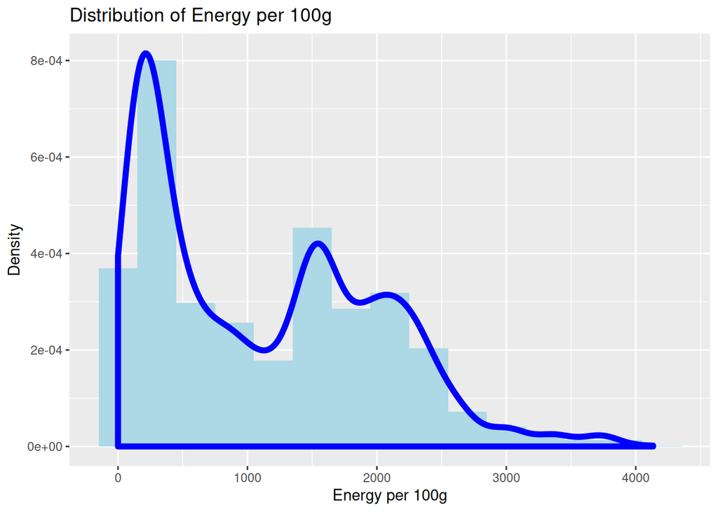

```r
g <- ggplot(food, aes(x = energy_100g)) +
    geom_histogram(aes(y = ..density..), fill = "lightblue", binwidth = 300) +
    geom_density(color = "blue", size = 2, adjust=0.8) +
    glabs
g
```

As we decrease the adjust parameter, the density plot tracks the data more closely and varies very quickly. As we increase it, the density smoothens out.

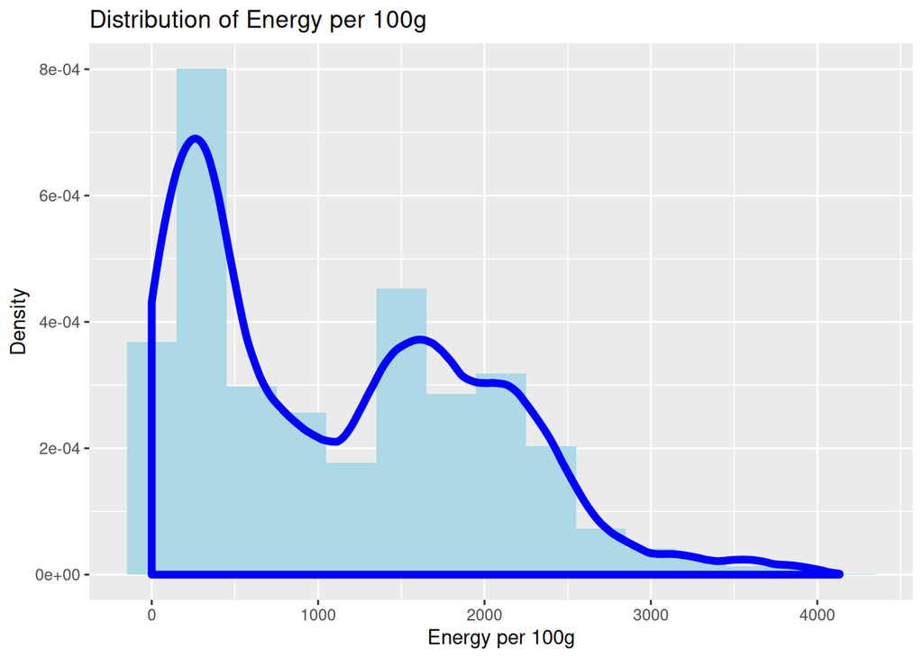

```r
g <- ggplot(food, aes(x = energy_100g)) +
    geom_histogram(aes(y = ..density..), fill = "lightblue", binwidth = 300) +
    geom_density(color = "blue", size = 2, kernel = "epanechnikov") +
    glabs
g
```

# Problem 3

(8 points each)

**Histograms and Density Plots for Conditional Distributions**

For parts (a), (b), (c), and (d), arrange the graphs into a 2x2 grid. For all parts, be sure to use proper titles, labels, colors, etc.

1. to d) Plots:

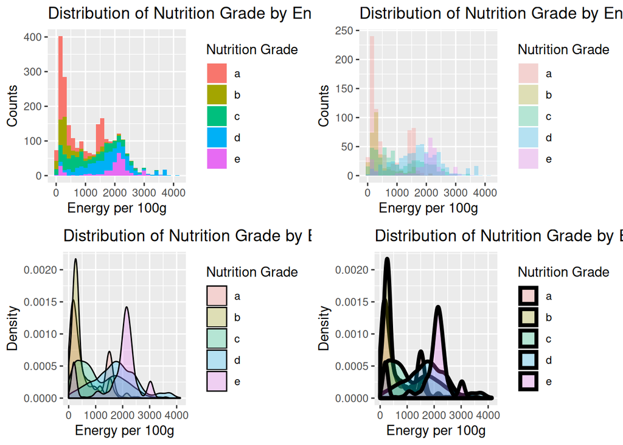

```r
glabs <- labs(x = "Energy per 100g", fill = "Nutrition Grade", y = "Counts",
              title = "Distribution of Nutrition Grade by Energy per 100g")
g1 <- ggplot(data = food, aes(x = energy_100g, fill = nutrition_grade_fr)) +
    geom_histogram() +
    glabs
g2 <- ggplot(data = food, aes(x = energy_100g, fill = nutrition_grade_fr)) +
    geom_histogram(alpha = 0.25, position = "identity") +
    glabs
g3 <- ggplot(data = food) +
    aes(x = energy_100g, fill = nutrition_grade_fr) +
    geom_density(alpha = 0.25, adjust = 0.8) + glabs +
    labs(y = "Density")
g4 <- ggplot(data = food) +
    aes(x = energy_100g, fill = nutrition_grade_fr) +
    geom_density(alpha = 0.25, adjust = 0.8, size = 1.5) + glabs +
    labs(y = "Density")
grid.arrange(g1, g2, g3, g4, ncol = 2, nrow = 2)
```

2. The alpha parameter sets the transparency of each bar in the histogram.
3. Size sets the thickness of the outline of the density plots.
4. Graph c) gives the most information about the conditional distributions, and is also the easiest to read, so it is the most effective overall.